# Las variables que afectan en el incremento del PBI

# Tema

¿Cómo influye la importación y exportación en el PBI anual de los países?

# Información

Se obtendrán los datos de la siguiente página [Portal de datos mundial](https://datos.bancomundial.org/)

[figure not shown]

# Preguntas a responder

La audiencia va a tener interés en el estudio debido a que la situación económica de cada país es un asunto de mucha relevancia, por lo que es esencial conocer el impacto de las importaciones y exportaciones en la economía, sobre todo las de minerales y metales en países exportadores como el nuestro. Asimismo, hemos considerado pertinente investigar también sobre las importaciones y exportaciones de los alimentos, combustibles y productos manufacturados, recolectados todos desde 1960. Con este estudio va a ser posible tener una mejor observación sobre la influencia de estas actividades comerciales en el PBI anual de un país, especialmente en los años 2019 y 2020, donde estas fueron alteradas por la emergencia sanitaria mundial.

●¿Qué información se desea aportar al final del estudio?

Buscamos partir con un estudio descriptivo de las importaciones y exportaciones de las materias primas o productos mencionados, para luego poder inferir relaciones entre las variables presentes en nuestro estudio. También, conseguiremos cifras de estos parámetros económicos para poder medirlos. Finalmente, nuestra intención es determinar si existe una correlación entre las importaciones y exportaciones con respecto al incremento o disminución del PBI anual, y después, también contrastaremos estas cifras obtenidas, a partir del uso de la data de importaciones y exportaciones, entre diferentes países, para poder determinar en cuales países tiene mayor influencia sobre sus economías respectivas.

Se trabajará con 219 países en los csv de importación, exportación y PBI, y cuenta con las mismas variables anualmente.

●¿Es posible llegar a la información que se propone de manera específica y concreta?

Es posible llegar a las conclusiones que hemos detallado porque tenemos mucha información y bases de datos de diferentes entidades, organizaciones y hasta empresas que nos aportan data fidedigna, segmentada y constante de cada año a partir de 1960.

- ¿Por qué se justifica nuestro estudio?

Es factible porque haremos uso de data recolectada por organismos internacionales de mucho prestigio, como el Banco Mundial, que cuentan con información de las importaciones y exportaciones de alimentos, combustibles y productos facturados de muchos países desde el año 1960, registrados anualmente, lo cual nos brinda un soporte fuerte para el desarrollo del proyecto.

Es específico porque el estudio está enfocado en obtener el impacto de estas actividades comerciales dentro de la economía de cada país y estudiar las variables y variaciones en el rango de tiempo mencionado.

Es auténtico porque no hay estudios exactamente sobre nuestro tema delimitado, no han sido segmentados específicamente para las importaciones y exportaciones mencionadas.

# Objetivos

General: Analizar el impacto de la importación y exportación de los alimentos, combustibles y productos manufacturados sobre la economía de cada país, precisamente en el crecimiento o disminución del PBI. Contrastar esta influencia entre diferentes países.

Específicos: - Corroborar si las variables afectan en el aumento del PBI o, hallar porque no afectan en algunos países, de ser el caso. - Relacionar las variables presentes en nuestro estudio.

# Marco teórico

Definiciones importantes: PBI: El Producto Bruto Interno es el valor total de los bienes y servicios finales producidos durante un período de tiempo en un territorio. Importaciones: Productos y mercancías ingresados desde el exterior con fines comerciales. Exportaciones: Productos y mercancías enviados a otros países externos con fines comerciales. Inflación: Aumento sostenido de consumo, bienes y servicios en una economía dentro de un período de tiempo.

Población objetivo: Se conforman por países que tienen estas actividades comerciales y las registren, por sus ministerios e instituciones, y también por organizaciones, entidades y empresas que estén involucradas en estas actividades o aporten información de las mismas.

# Base de datos:

# Base de datos de PBI:

El data frame PBI sería:

| Nombre de los paises | 1960 | 1961 | 1962 | 1963 | 1964 | 1965 | 1966 | 1967 | 1968 | 1969 | 1970 | 1971 | 1972 | 1973 | 1974 | 1975 | 1976 | 1977 | 1978 | 1979 | 1980 | 1981 | 1982 | 1983 | 1984 | 1985 | 1986 | 1987 | 1988 | … |
| --- | --- | --- | --- | --- | --- | --- | --- | --- | --- | --- | --- | --- | --- | --- | --- | --- | --- | --- | --- | --- | --- | --- | --- | --- | --- | --- | --- | --- | --- | --- |
| Aruba | NA | NA | NA | NA | NA | NA | NA | NA | NA | NA | NA | NA | NA | NA | NA | NA | NA | NA | NA | NA | NA | NA | NA | NA | NA | NA | NA | 18 | 20 | … |
| Afganistán | NA | NA | NA | NA | NA | NA | NA | NA | NA | NA | NA | NA | NA | NA | NA | NA | NA | NA | NA | NA | NA | NA | NA | NA | NA | NA | NA | NA | NA | … |
| Angola | NA | NA | NA | NA | NA | NA | NA | NA | NA | NA | NA | NA | NA | NA | NA | NA | NA | NA | NA | NA | NA | -8 | -3 | 1 | 2 | 0 | -1 | 0 | 2 | … |
| Albania | NA | NA | NA | NA | NA | NA | NA | NA | NA | NA | NA | NA | NA | NA | NA | NA | NA | NA | NA | NA | NA | 4 | 1 | -1 | -3 | 0 | 4 | -3 | -3 | … |
| Andorra | NA | NA | NA | NA | NA | NA | NA | NA | NA | NA | NA | -1 | 3 | 3 | 1 | -3 | 0 | 0 | -1 | -3 | -1 | -4 | -3 | -3 | -3 | -2 | -1 | 1 | 1 | … |
| El mundo árabe | NA | NA | NA | NA | NA | NA | NA | NA | NA | NA | NA | NA | NA | NA | NA | NA | 12 | 5 | -4 | 8 | 6 | 0 | -12 | -9 | -1 | -5 | 2 | -3 | 3 | … |

Cantidad de datos faltantes en la base de datos.

```
## [1] 4079
```

Cantidad de observaciones incompletas en la base de datos

```
## [1] 264
```

Calculamos el porcentaje que representan los datos faltantes en nuestra base de datos.

```
## [1] 24.92
```

Calculamos los datos faltantes por cada variable para ver cómo los NA afectan a cada una de ellas.

```
## Nombre de los paises                 1960                 1961
##                    0                  264                  144
##                 1962                 1963                 1964
##                  141                  141                  141
##                 1965                 1966                 1967
##                  141                  133                  129
##                 1968                 1969                 1970
##                  127                  123                  126
##                 1971                 1972                 1973
##                  112                  112                  112
##                 1974                 1975                 1976
##                  112                  110                  106
##                 1977                 1978                 1979
##                  104                   98                   98
##                 1980                 1981                 1982
```

[output cut: 27 more lines]

El data frame Exportación de minerales y metales sería:

| Nombre de los paises | 1960 | 1961 | 1962 | 1963 | 1964 | 1965 | 1966 | 1967 | 1968 | 1969 | 1970 | 1971 | 1972 | 1973 | 1974 | 1975 | 1976 | 1977 | 1978 | 1979 | 1980 | 1981 | 1982 | 1983 | 1984 | 1985 | 1986 | 1987 | 1988 | … |
| --- | --- | --- | --- | --- | --- | --- | --- | --- | --- | --- | --- | --- | --- | --- | --- | --- | --- | --- | --- | --- | --- | --- | --- | --- | --- | --- | --- | --- | --- | --- |
| Aruba | NA | NA | NA | NA | NA | NA | NA | NA | NA | NA | NA | NA | NA | NA | NA | NA | NA | NA | NA | NA | NA | NA | NA | NA | NA | NA | NA | NA | NA | … |
| Afganistán | NA | NA | NA | NA | NA | NA | 0 | 0 | NA | NA | NA | NA | NA | NA | 0 | NA | 0 | 0 | NA | NA | NA | NA | NA | NA | NA | NA | NA | NA | NA | … |
| Angola | NA | NA | 4 | NA | NA | NA | NA | NA | NA | 12 | 12 | 10 | 8 | 7 | 4 | NA | NA | NA | 0 | 0 | 0 | 0 | NA | NA | NA | NA | NA | NA | NA | … |
| Albania | NA | NA | NA | NA | NA | NA | NA | NA | NA | NA | NA | NA | NA | NA | NA | NA | NA | NA | NA | NA | NA | NA | NA | NA | NA | NA | NA | NA | NA | … |
| Andorra | NA | NA | NA | NA | NA | NA | NA | NA | NA | NA | NA | NA | NA | NA | NA | NA | NA | NA | NA | NA | NA | NA | NA | NA | NA | NA | NA | NA | NA | … |
| El mundo árabe | NA | NA | NA | NA | NA | NA | NA | NA | NA | NA | NA | NA | NA | NA | NA | NA | NA | NA | 2 | 3 | NA | NA | NA | NA | NA | NA | NA | NA | NA | … |

Cantidad de datos faltantes en la base de datos.

```
## [1] 7487
```

Cantidad de observaciones incompletas en la base de datos

```
## [1] 264
```

Calculamos el porcentaje que representan los datos faltantes en nuestra base de datos.

```
## [1] 45.74
```

Calculamos los datos faltantes por cada variable para ver cómo los NA afectan a cada una de ellas.

```
## Nombre de los paises                 1960                 1961
##                    0                  264                  264
##                 1962                 1963                 1964
##                  180                  173                  174
##                 1965                 1966                 1967
##                  168                  163                  161
##                 1968                 1969                 1970
##                  159                  160                  141
##                 1971                 1972                 1973
##                  137                  132                  130
##                 1974                 1975                 1976
##                  119                  120                  121
##                 1977                 1978                 1979
##                  126                  123                  128
##                 1980                 1981                 1982
```

[output cut: 27 more lines]

El data frame Importación de minerales y metales sería:

| Nombre de los paises | 1960 | 1961 | 1962 | 1963 | 1964 | 1965 | 1966 | 1967 | 1968 | 1969 | 1970 | 1971 | 1972 | 1973 | 1974 | 1975 | 1976 | 1977 | 1978 | 1979 | 1980 | 1981 | 1982 | 1983 | 1984 | 1985 | 1986 | 1987 | 1988 | … |
| --- | --- | --- | --- | --- | --- | --- | --- | --- | --- | --- | --- | --- | --- | --- | --- | --- | --- | --- | --- | --- | --- | --- | --- | --- | --- | --- | --- | --- | --- | --- |
| Aruba | NA | NA | NA | NA | NA | NA | NA | NA | NA | NA | NA | NA | NA | NA | NA | NA | NA | NA | NA | NA | NA | NA | NA | NA | NA | NA | NA | NA | NA | … |
| Afganistán | NA | NA | 0 | 0 | 0 | 0 | 0 | 0 | 0 | 0 | 0 | 0 | 0 | 0 | 0 | 0 | 0 | 0 | NA | NA | NA | NA | NA | NA | NA | NA | NA | NA | NA | … |
| Angola | NA | NA | 1 | NA | NA | NA | NA | NA | NA | 1 | 1 | 1 | 1 | 2 | 3 | NA | NA | NA | NA | NA | NA | NA | NA | NA | NA | 1 | NA | NA | NA | … |
| Albania | NA | NA | NA | NA | NA | NA | NA | NA | NA | NA | NA | NA | NA | NA | NA | NA | NA | NA | NA | NA | NA | NA | NA | NA | NA | NA | NA | NA | NA | … |
| Andorra | NA | NA | NA | NA | NA | NA | NA | NA | NA | NA | NA | NA | NA | NA | NA | NA | NA | NA | NA | NA | NA | NA | NA | NA | NA | NA | NA | NA | NA | … |
| El mundo árabe | NA | NA | NA | NA | NA | NA | NA | NA | NA | NA | NA | NA | NA | NA | NA | NA | NA | NA | 1 | 1 | 2 | 1 | 1 | 2 | NA | NA | NA | NA | NA | … |

Cantidad de datos faltantes en la base de datos.

```
## [1] 7320
```

Cantidad de observaciones incompletas en la base de datos

```
## [1] 264
```

Calculamos el porcentaje que representan los datos faltantes en nuestra base de datos.

```
## [1] 44.72
```

Calculamos los datos faltantes por cada variable para ver cómo los NA afectan a cada una de ellas.

```
## Nombre de los paises                 1960                 1961
##                    0                  264                  264
##                 1962                 1963                 1964
##                  178                  173                  172
##                 1965                 1966                 1967
##                  166                  163                  160
##                 1968                 1969                 1970
##                  158                  160                  140
##                 1971                 1972                 1973
##                  138                  132                  132
##                 1974                 1975                 1976
##                  121                  115                  115
##                 1977                 1978                 1979
##                  117                  120                  123
##                 1980                 1981                 1982
```

[output cut: 27 more lines]

## Exportación de minerales y metales en los años 1960-2020

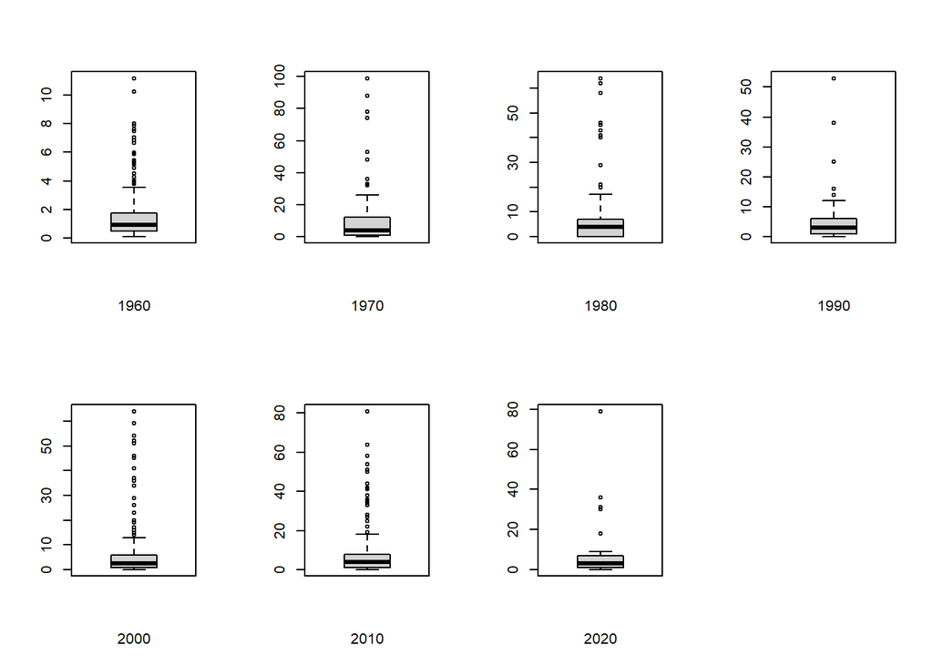

#### Descripción de las gráficas :

- En el año 1960, el diagrama caja y bigotes esta comprimido y hay diversos datos atípicos.
- En el año 1970, hay diversos datos atípicos en el diagrama y su rango intercuartil es más ancho que lo que sucedió en 1960.
- En el año 1980,entre el primer cuartil y la mediana, los datos están más dispersos, lo que la proporción en el caja y bigotes se vea más ancho.
- En el año 1990,los datos atípicos disminuyeron con respecto al año 1980.
- En el año 2000, hay demasiados datos atípicos que llegan a un 60% de crecimiento de exportaciones de minerales y metales y el caja y bigotes esta comprimido.
- En el año 2010, hay un país que tiene la mayor cantidad de exportaciones y minerales y el que tiene el mayor crecimiento con respeco al año anterior, los datos atípicos se siguen manteniendo .
- En el año 2020, los datos atípicos han disminuido a diferencia del año 2010.

## Importación de minerales y metales en los años 1960-2020

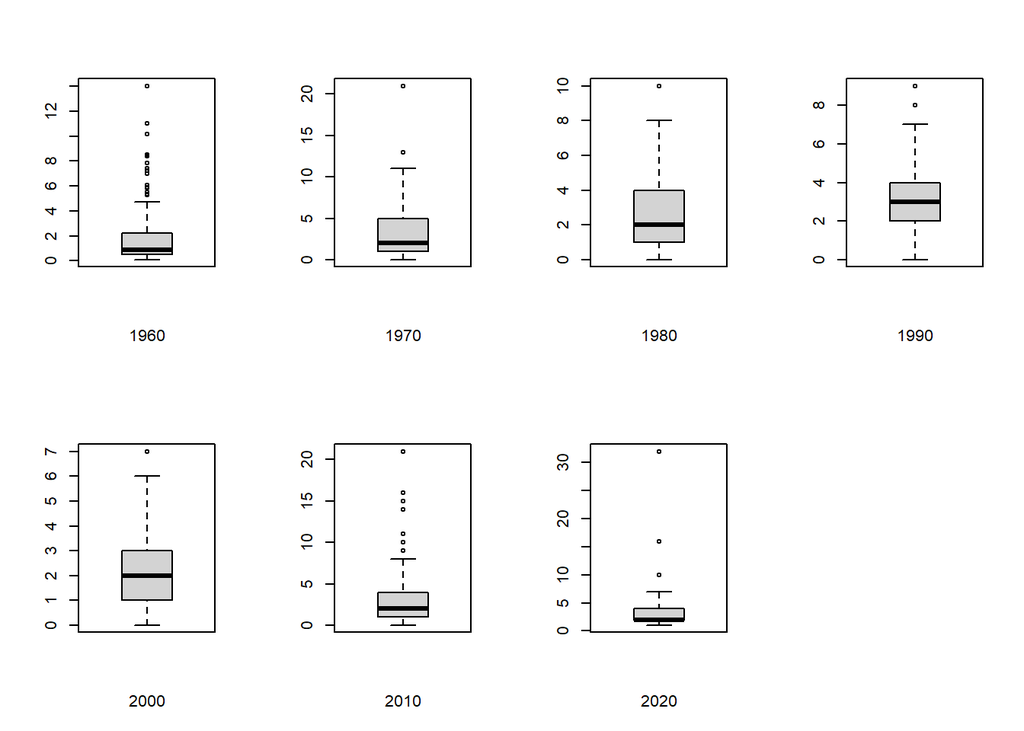

## INTERVALO DE CONFIANZA

Consideraremos apropiado un nivel de confianza del 90%

IC PBI de los países en el 2010

```
## ( 2.928682 , 3.095318 )
```

En el año 2010, el intervalo era positivo, lo que nos mostraba que el promedio de los países estaba creciendo.

IC PBI de los países en el 2020

```
## ( -5.647744 , -6.042522 )
```

Comparando con el año 2010, el intervalo muestra un decrecimiento.

IC Exportación de minerales y metales 2010

```
## ( 7.912912 , 8.349999 )
```

El intervalo es alto, demuestra que la media alcanzada por la exportación de minerales y metales en el 2010 tuvieron un gran crecimiento en sus exportaciones con respecto al año anterior .

IC Exportación de minerales y metales 2020

```
## ( 8.337429 , 8.787571 )
```

Si lo comparamos con el 2010, las exportaciones de minerales y metales ha estado creciendo y eso lo demuestra el rango alto que sigue manteniendo

IC Importación de minerales y metales 2010

```
## ( 2.829451 , 2.994623 )
```

En el 2010, el rango de las importaciones de minerales y metales demuestra un crecimiento en las importaciones con respecto al año anterior.

IC Importación de minerales y metales 2020

```
## ( 4.133568 , 4.366432 )
```

Si lo comparamos con el 2010, las importaciones de minerales y metales ha estado creciendo y eso lo demuestra el rango alto que sigue manteniendo.

### Conclusiones

1. Como hemos comparado el PBI de los años 2010 y 2020, en este último su promedio es decreciente, una de las razones es que si bien algunas variables como importación y exportación de minerales y metales creció en el 2020, se puede deducir que otras no.
2. Las exportaciones e importaciones de minerales y metales mantuvo un crecimiento en el 2020, la pandemia del covid_19_ no le afectó, esto es porque si bien ciertos productos se dejaron de adquirir, pero el libre comercio continuo, se siguió produciendo y las personas siguieron adquiriendo productos como laptops, computadoras, entre otros.

## HIPÓTESIS I

H0 = En promedio el PBI de los países es igual y mayor 4% con respecto al año 2000

H0 = µ >= 4

H1 = En promedio el PBI de los países es menor a 4% con respecto al año 2000

H1 = µ < 4

Nivel de significancia : 10%

Valor Crítico:

```
## [1] 3.680586
```

Estadístico para esta prueba de hipótesis:

```
## [1] 2.848101
```

Podemos observar que nuestro estadístico está en la región de rechazo.

Esto lo corroboramos con nuestro p-valor:

```
## [1] 1.903569e-06
```

##### Conclusión Hipótesis I

Según el análisis de la distribución de probabilidad de la variable PBI en el año 2000, el valor de z crítico que delimita la zona de rechazo es 3.68. Asimismo, el valor estadístico es 2.85 y se ubica en la zona de rechazo. *Es por esto que la hipótesis nula será rechazada*.

## HIPÓTESIS II

H0 = El promedio del crecimiento de las exportaciones de minerales y metales es igual a 10 en el año 2020

H0 = µ >= 10

H1 = El promedio del crecimiento de las exportaciones de minerales y metales no es igual a 10 en el año 2020.

H1 = µ < 10

Nivel de significancia : 10%

Valor Crítico :

```
## [1] 8.593387
```

Estadístico para esta prueba de hipótesis:

```
## [1] 8.5625
```

Esto lo corroboramos con nuestro p-valor:

```
## [1] 0.09514999
```

##### Conclusión Hipótesis II

Según el análisis de la distribución de probabilidad de la variable exportaciones de minerales y metales en el año 2020, el valor de z crítico que delimita la zona de rechazo es 8.59 . Asimismo, el valor estadístico es 8.56 y se ubica en la zona de rechazo. *Es por esto que la hipótesis nula será rechazada*.

## HIPÓTESIS III

H0 = El promedio del crecimiento de las exportaciones de productos manufacturados es mayor igual a 60 en el año 2020.

H0 = µ >= 60

H1 = El promedio del crecimiento de las exportaciones de productos manufacturados es menor a 60 en el año 2020.

H1 = µ < 60

Nivel de significancia : 10%

Valor Crítico:

```
## [1] 57.50592
```

Estadístico para esta prueba de hipótesis:

```
## [1] 55.71875
```

Esto lo corroboramos con nuestro p-valor:

```
## [1] 0.01390831
```

# Regresión 1

### Exportación e Importación de productos manufacturados

Analizamos las diferentes variables de nuestro data.frame y nos dimos cuenta que existe una correlación en el año de 1970 de la relación de las exportaciones y las importaciones de productos manufacturados.

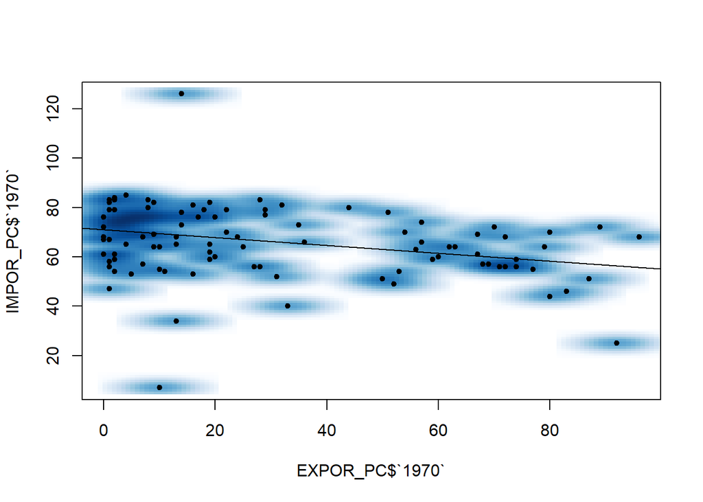

```r
smoothScatter(IMPOR_PC$`1970`~EXPOR_PC$`1970`,pch=20)
abline(lm(IMPOR_PC$`1970`~EXPOR_PC$`1970`))
```

## Regresión 1: Summary

```r
lm0<-lm(IMPOR_PC$`1970`~EXPOR_PC$`1970`)
summary(lm0)
```

```
##
## Call:
## lm(formula = IMPOR_PC$`1970` ~ EXPOR_PC$`1970`)
##
## Residuals:
##     Min      1Q  Median      3Q     Max
## -62.480  -5.838   0.903   7.859  57.162
##
## Coefficients:
##                 Estimate Std. Error t value Pr(>|t|)
## (Intercept)      71.0852     1.6147  44.023  < 2e-16 ***
## EXPOR_PC$`1970`  -0.1605     0.0415  -3.868 0.000178 ***
## ---
## Signif. codes:  0 '***' 0.001 '**' 0.01 '*' 0.05 '.' 0.1 ' ' 1
##
## Residual standard error: 12.86 on 121 degrees of freedom
##   (141 observations deleted due to missingness)
## Multiple R-squared:   0.11,  Adjusted R-squared:  0.1027
## F-statistic: 14.96 on 1 and 121 DF,  p-value: 0.0001781
```

```r
#plot(lm0)
```

#### Prueba de hipótesis del intercepto

El coeficiente del intercepto es “< 2e-16”

Nivel de significancia : 10%

H0 : El coeficiente es 0

H1: El coeficiente es diferente de 0

Al ser estos numero más pequeño que 10%, *se rechaza H0* para cada coeficiente.

#### Hipótesis p-valor

Nivel de significancia : 10%

p-valor = 0.0001781

H0: el modelo no explica nada

H1: el modelo explica algo

*Se rechaza H0*, puesto que p-valor <0.1

El modelo es significativo

#### Coeficientes de regresión

Nuestra ecuación se forma con los siguientes coeficientes: </br>

```r
coef(lm0,1)
```

```
##     (Intercept) EXPOR_PC$`1970`
##      71.0852373      -0.1605058
```

$$B0= 71.085$$
$$B1= -0.161$$

$$y(x) = -0.161x +71.085$$

#### Coeficiente de determinación

Adjusted R-squared: 0.1027

Multiple R-squared: 0.11

Estos dos números van a ser muy parecidos, nos dice que grado de variación de Y explicamos . En este caso 89% no se logró explicar, pero esta variación ha variado en -0.16.

## Regresión 1: Gráfica de homocedasticidad

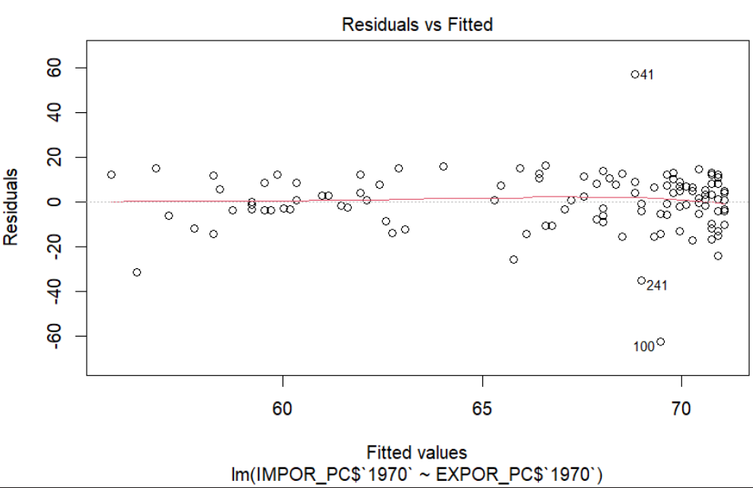

Los residuos son heterocedásticos ya que no se distribuyen uniformemente alrededor de la línea roja.

## Regresión 1:Gráfica de distribución de los residuos

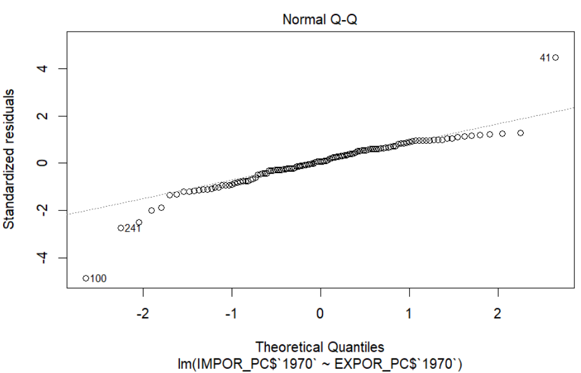

Se puede ver que existe algunas desviaciones con respecto a la normalidad de los residuos. En las esquinas observamos, que los datos observados son menores que los esperados, por eso aparece por debajo de nuestra línea normal.

# Regresión 2

Analizamos las diferentes variables de nuestro data.frame y nos dimos cuenta que existe una correlación entre la variable Importación y exportación de minerales y metales en el año 1970.

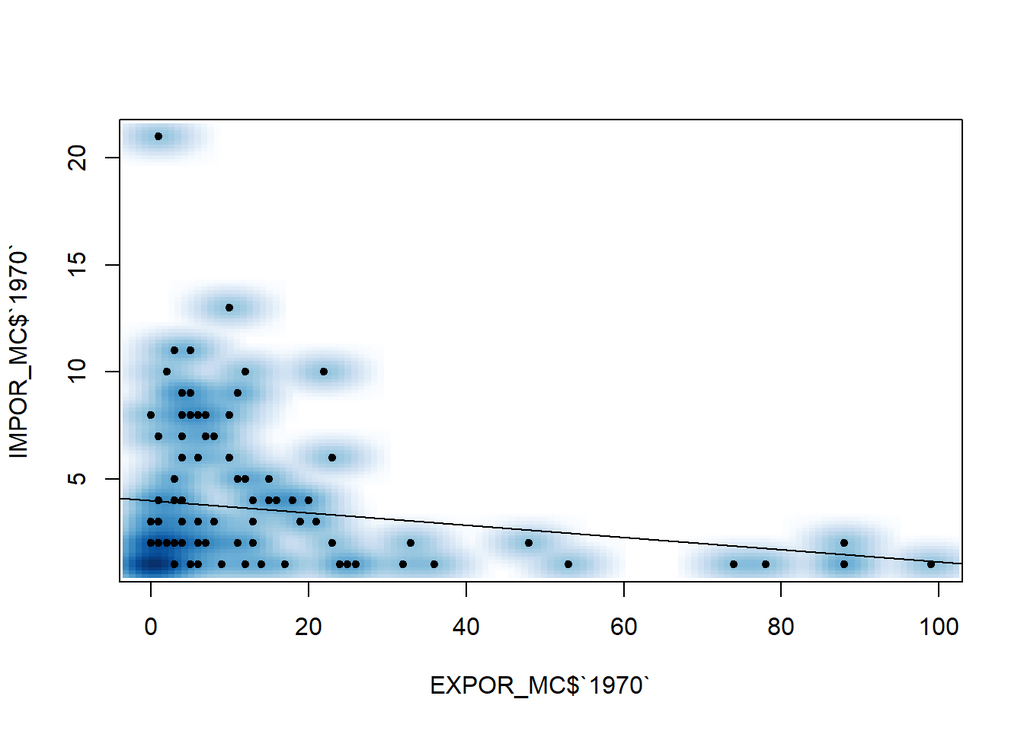

## Regresión 2: Summary

```r
summary(lm1)
```

```
##
## Call:
## lm(formula = IMPOR_MC$`1970` ~ EXPOR_MC$`1970`)
##
## Residuals:
##     Min      1Q  Median      3Q     Max
## -2.9940 -2.2450 -0.9652  1.3229 17.0348
##
## Coefficients:
##                 Estimate Std. Error t value Pr(>|t|)
## (Intercept)      3.99400    0.35069  11.389   <2e-16 ***
## EXPOR_MC$`1970` -0.02881    0.01544  -1.866   0.0645 .
## ---
## Signif. codes:  0 '***' 0.001 '**' 0.01 '*' 0.05 '.' 0.1 ' ' 1
##
## Residual standard error: 3.321 on 119 degrees of freedom
##   (143 observations deleted due to missingness)
## Multiple R-squared:  0.02843,    Adjusted R-squared:  0.02026
## F-statistic: 3.482 on 1 and 119 DF,  p-value: 0.0645
```

#### Prueba de hipótesis del intercepto

El coeficiente del intercepto es “< 2e-16”

Nivel de significancia : 10%

H0 : El coeficiente es 0

H1: El coeficiente es diferente de 0

Al ser estos numero más pequeño que 10%, *se rechaza H0* para cada coeficiente.

#### Hipótesis p-valor

Nivel de significancia : 10%

p-valor = 0.0645

H0: el modelo no explica nada

H1: el modelo explica algo

*Se rechaza H0*, puesto que p-valor <0.1

El modelo es significativo

#### Coeficientes de regresión

Nuestra ecuación se forma con los siguientes coeficientes:

```r
coef(lm1,1)
```

```
##     (Intercept) EXPOR_MC$`1970`
##      3.99399869     -0.02880818
```

$$B0= 3.993$$
$$B1= -0.029$$

$$y(x)=3.993-0.029x$$

#### Coeficiente de determinación

Adjusted R-squared: 0.02026

Multiple R-squared: 0.02843

Estos dos números van a ser muy parecidos, nos dice que grado de variación de Y explicamos . En este caso 97.2% no se logró explicar, pero esta variación ha variado en -0.029.

## Regresión 2: Gráfica de homocedasticidad

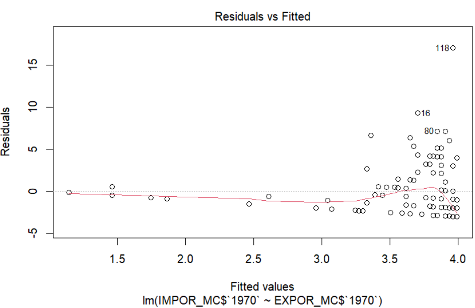

Los residuos son heterocedásticos ya que no se distribuyen uniformemente alrededor de la línea roja.